# Divyam Bansal Ensemble Learning

```python
from IPython.display import HTML

HTML('''<script>
code_show=true;
function code_toggle() {
 if (code_show){
 $('div.input').hide();
 } else {
 $('div.input').show();
 }
 code_show = !code_show
}
$( document ).ready(code_toggle);
</script>
<form action="javascript:code_toggle()"><input type="submit" value="Click here to toggle on/off the code."></form>
''')
```

## 1. Install the necessary libraries and read the provided dataset.

Importing Libraries from sklearn to run various classifiers

```python
import numpy as np
import pandas as pd
import matplotlib.pyplot as plt
import seaborn as sns
import warnings
warnings.filterwarnings("ignore")

from sklearn.model_selection import train_test_split
from sklearn.preprocessing import StandardScaler
from sklearn import metrics
from sklearn import tree
from sklearn.tree import DecisionTreeRegressor
from sklearn.ensemble import RandomForestRegressor
from sklearn.ensemble import RandomForestClassifier
from sklearn.ensemble import GradientBoostingClassifier
from sklearn.ensemble import StackingClassifier
from mlxtend.regressor import StackingRegressor
```

Reading the data set and saving it as dataframe named 'apps'

```python
apps =  pd.read_csv('Apps_data+(1).csv')
```

## 2. a. Check the info and summary statistics of the dataset. List out the columns that need to be worked upon for model building.

```python
apps.T
```

|  | 0 | 1 | 2 | 3 | 4 | 5 | 6 | 7 | 8 | 9 | ... | 10831 | 10832 | 10833 | 10834 | 10835 | 10836 | 10837 | 10838 | 10839 | 10840 |
| --- | --- | --- | --- | --- | --- | --- | --- | --- | --- | --- | --- | --- | --- | --- | --- | --- | --- | --- | --- | --- | --- |
| App | Photo Editor & Candy Camera & Grid & ScrapBook | Coloring book moana | U Launcher Lite – FREE Live Cool Themes, Hide ... | Sketch - Draw & Paint | Pixel Draw - Number Art Coloring Book | Paper flowers instructions | Smoke Effect Photo Maker - Smoke Editor | Infinite Painter | Garden Coloring Book | Kids Paint Free - Drawing Fun | ... | payermonstationnement.fr | FR Tides | Chemin (fr) | FR Calculator | FR Forms | Sya9a Maroc - FR | Fr. Mike Schmitz Audio Teachings | Parkinson Exercices FR | The SCP Foundation DB fr nn5n | iHoroscope - 2018 Daily Horoscope & Astrology |
| Category | ART_AND_DESIGN | ART_AND_DESIGN | ART_AND_DESIGN | ART_AND_DESIGN | ART_AND_DESIGN | ART_AND_DESIGN | ART_AND_DESIGN | ART_AND_DESIGN | ART_AND_DESIGN | ART_AND_DESIGN | ... | MAPS_AND_NAVIGATION | WEATHER | BOOKS_AND_REFERENCE | FAMILY | BUSINESS | FAMILY | FAMILY | MEDICAL | BOOKS_AND_REFERENCE | LIFESTYLE |
| Rating | 4.1 | 3.9 | 4.7 | 4.5 | 4.3 | 4.4 | 3.8 | 4.1 | 4.4 | 4.7 | ... | NaN | 3.8 | 4.8 | 4.0 | NaN | 4.5 | 5.0 | NaN | 4.5 | 4.5 |
| Reviews | 159 | 967 | 87510 | 215644 | 967 | 167 | 178 | 36815 | 13791 | 121 | ... | 38 | 1195 | 44 | 7 | 0 | 38 | 4 | 3 | 114 | 398307 |
| Size | 19M | 14M | 8.7M | 25M | 2.8M | 5.6M | 19M | 29M | 33M | 3.1M | ... | 9.8M | 582k | 619k | 2.6M | 9.6M | 53M | 3.6M | 9.5M | Varies with device | 19M |
| Installs | 10,000+ | 500,000+ | 5,000,000+ | 50,000,000+ | 100,000+ | 50,000+ | 50,000+ | 1,000,000+ | 1,000,000+ | 10,000+ | ... | 5,000+ | 100,000+ | 1,000+ | 500+ | 10+ | 5,000+ | 100+ | 1,000+ | 1,000+ | 10,000,000+ |
| Type | Free | Free | Free | Free | Free | Free | Free | Free | Free | Free | ... | Free | Free | Free | Free | Free | Free | Free | Free | Free | Free |
| Price | 0 | 0 | 0 | 0 | 0 | 0 | 0 | 0 | 0 | 0 | ... | 0 | 0 | 0 | 0 | 0 | 0 | 0 | 0 | 0 | 0 |
| Content Rating | Everyone | Everyone | Everyone | Teen | Everyone | Everyone | Everyone | Everyone | Everyone | Everyone | ... | Everyone | Everyone | Everyone | Everyone | Everyone | Everyone | Everyone | Everyone | Mature 17+ | Everyone |
| Genres | Art & Design | Art & Design;Pretend Play | Art & Design | Art & Design | Art & Design;Creativity | Art & Design | Art & Design | Art & Design | Art & Design | Art & Design;Creativity | ... | Maps & Navigation | Weather | Books & Reference | Education | Business | Education | Education | Medical | Books & Reference | Lifestyle |
| Last Updated | January 7, 2018 | January 15, 2018 | August 1, 2018 | June 8, 2018 | June 20, 2018 | March 26, 2017 | April 26, 2018 | June 14, 2018 | September 20, 2017 | July 3, 2018 | ... | June 13, 2018 | February 16, 2014 | March 23, 2014 | June 18, 2017 | September 29, 2016 | July 25, 2017 | July 6, 2018 | January 20, 2017 | January 19, 2015 | July 25, 2018 |
| Current Ver | 1.0.0 | 2.0.0 | 1.2.4 | Varies with device | 1.1 | 1.0 | 1.1 | 6.1.61.1 | 2.9.2 | 2.8 | ... | 2.0.148.0 | 6.0 | 0.8 | 1.0.0 | 1.1.5 | 1.48 | 1.0 | 1.0 | Varies with device | Varies with device |
| Android Ver | 4.0.3 and up | 4.0.3 and up | 4.0.3 and up | 4.2 and up | 4.4 and up | 2.3 and up | 4.0.3 and up | 4.2 and up | 3.0 and up | 4.0.3 and up | ... | 4.0 and up | 2.1 and up | 2.2 and up | 4.1 and up | 4.0 and up | 4.1 and up | 4.1 and up | 2.2 and up | Varies with device | Varies with device |

13 rows × 10841 columns

Data set has 10841 vaues in 13 different columns

```python
apps.info()
```

```
<class 'pandas.core.frame.DataFrame'>
RangeIndex: 10841 entries, 0 to 10840
Data columns (total 13 columns):
 #   Column          Non-Null Count  Dtype
---  ------          --------------  -----
 0   App             10841 non-null  object
 1   Category        10841 non-null  object
 2   Rating          9367 non-null   float64
 3   Reviews         10841 non-null  object
 4   Size            10841 non-null  object
 5   Installs        10841 non-null  object
 6   Type            10840 non-null  object
 7   Price           10841 non-null  object
 8   Content Rating  10840 non-null  object
 9   Genres          10841 non-null  object
 10  Last Updated    10841 non-null  object
 11  Current Ver     10833 non-null  object
 12  Android Ver     10838 non-null  object
dtypes: float64(1), object(12)
memory usage: 1.1+ MB
```

A few columns have null values which needs to be looked upon

```python
apps.describe()
```

|  | Rating |
| --- | --- |
| count | 9367.000000 |
| mean | 4.193338 |
| std | 0.537431 |
| min | 1.000000 |
| 25% | 4.000000 |
| 50% | 4.300000 |
| 75% | 4.500000 |
| max | 19.000000 |

```python
apps.isnull().sum()
```

```
App                  0
Category             0
Rating            1474
Reviews              0
Size                 0
Installs             0
Type                 1
Price                0
Content Rating       1
Genres               0
Last Updated         0
Current Ver          8
Android Ver          3
dtype: int64
```

- We can see that there are null values present in Rating, Type, Content Rating, Current ver and Android Ver, so these column should be worked upon.
- the data type of many column should be changd from object to numerical type like Reviews, Size and Install

## b. Check if there are any duplicate entries for the apps

```python
apps['App'].value_counts()
```

```
ROBLOX                                                9
CBS Sports App - Scores, News, Stats & Watch Live     8
ESPN                                                  7
Duolingo: Learn Languages Free                        7
Candy Crush Saga                                      7
                                                     ..
Meet U - Get Friends for Snapchat, Kik & Instagram    1
U-Report                                              1
U of I Community Credit Union                         1
Waiting For U Launcher Theme                          1
iHoroscope - 2018 Daily Horoscope & Astrology         1
Name: App, Length: 9660, dtype: int64
```

We can see there are multiple apps with duplicate calues which needs to be corrected

## c. Check if there are any wrong values in the ‘Category’ column and impute them with relevant values.

```python
apps.Category.unique()
```

```
array(['ART_AND_DESIGN', 'AUTO_AND_VEHICLES', 'BEAUTY',
       'BOOKS_AND_REFERENCE', 'BUSINESS', 'COMICS', 'COMMUNICATION',
       'DATING', 'EDUCATION', 'ENTERTAINMENT', 'EVENTS', 'FINANCE',
       'FOOD_AND_DRINK', 'HEALTH_AND_FITNESS', 'HOUSE_AND_HOME',
       'LIBRARIES_AND_DEMO', 'LIFESTYLE', 'GAME', 'FAMILY', 'MEDICAL',
       'SOCIAL', 'SHOPPING', 'PHOTOGRAPHY', 'SPORTS', 'TRAVEL_AND_LOCAL',
       'TOOLS', 'PERSONALIZATION', 'PRODUCTIVITY', 'PARENTING', 'WEATHER',
       'VIDEO_PLAYERS', 'NEWS_AND_MAGAZINES', 'MAPS_AND_NAVIGATION',
       '1.9'], dtype=object)
```

- The Value 1.9 is not the right value for category column.

```python
apps.loc[apps['Category'] == '1.9'].T
```

|  | 10472 |
| --- | --- |
| App | Life Made WI-Fi Touchscreen Photo Frame |
| Category | 1.9 |
| Rating | 19.0 |
| Reviews | 3.0M |
| Size | 1,000+ |
| Installs | Free |
| Type | 0 |
| Price | Everyone |
| Content Rating | NaN |
| Genres | February 11, 2018 |
| Last Updated | 1.0.19 |
| Current Ver | 4.0 and up |
| Android Ver | NaN |

- After checking the row with category 1.9 we see all the values of this row is sifted to left so we shift all the values to right one column anddrop duplicate rows

```python
apps.iloc[10472,1:] = apps.iloc[10472,1:].shift(1)
apps[10471:10473].T
```

|  | 10471 | 10472 |
| --- | --- | --- |
| App | Xposed Wi-Fi-Pwd | Life Made WI-Fi Touchscreen Photo Frame |
| Category | PERSONALIZATION | NaN |
| Rating | 3.5 | 1.9 |
| Reviews | 1042 | 19.0 |
| Size | 404k | 3.0M |
| Installs | 100,000+ | 1,000+ |
| Type | Free | Free |
| Price | 0 | 0 |
| Content Rating | Everyone | Everyone |
| Genres | Personalization | NaN |
| Last Updated | August 5, 2014 | February 11, 2018 |
| Current Ver | 3.0.0 | 1.0.19 |
| Android Ver | 4.0.3 and up | 4.0 and up |

```python
apps['Category'] = apps['Category'].replace([np.nan],'LIFESTYLE')
```

- Repacinh Nan in category with relevant Value

```python
apps.drop_duplicates(subset ="App",keep = False, inplace = True)
```

## d. Which category has the highest number of apps?

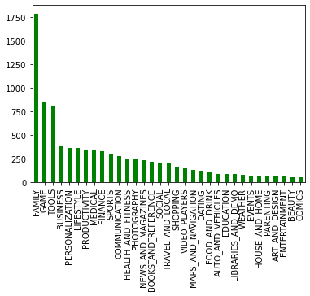

```python
apps.Category.value_counts().plot(kind='bar',color='g')
```

- There are most number of apps under Category: Family

## e. Check the distribution of rating column and convert ratings into two categories and save it in the data frame as ‘Rating_cat’ ( high = +>3.5 and remaining as low)

```python
apps["Rating"] = pd.to_numeric(apps["Rating"])
```

```python
x=apps.Rating.median()
apps.Rating.fillna(x,inplace=True)
```

```python
def rating_cat(row):
    if row['Rating'] >= 3.5 :
        return 'High'
    elif row['Rating'] < 3.5:
        return 'Low'
```

```python
apps['Rating_cat']=apps.apply(lambda row:rating_cat(row), axis=1)
```

```python
apps.T
```

|  | 0 | 2 | 3 | 4 | 5 | 6 | 7 | 8 | 9 | 10 | ... | 10831 | 10832 | 10833 | 10834 | 10835 | 10836 | 10837 | 10838 | 10839 | 10840 |
| --- | --- | --- | --- | --- | --- | --- | --- | --- | --- | --- | --- | --- | --- | --- | --- | --- | --- | --- | --- | --- | --- |
| App | Photo Editor & Candy Camera & Grid & ScrapBook | U Launcher Lite – FREE Live Cool Themes, Hide ... | Sketch - Draw & Paint | Pixel Draw - Number Art Coloring Book | Paper flowers instructions | Smoke Effect Photo Maker - Smoke Editor | Infinite Painter | Garden Coloring Book | Kids Paint Free - Drawing Fun | Text on Photo - Fonteee | ... | payermonstationnement.fr | FR Tides | Chemin (fr) | FR Calculator | FR Forms | Sya9a Maroc - FR | Fr. Mike Schmitz Audio Teachings | Parkinson Exercices FR | The SCP Foundation DB fr nn5n | iHoroscope - 2018 Daily Horoscope & Astrology |
| Category | ART_AND_DESIGN | ART_AND_DESIGN | ART_AND_DESIGN | ART_AND_DESIGN | ART_AND_DESIGN | ART_AND_DESIGN | ART_AND_DESIGN | ART_AND_DESIGN | ART_AND_DESIGN | ART_AND_DESIGN | ... | MAPS_AND_NAVIGATION | WEATHER | BOOKS_AND_REFERENCE | FAMILY | BUSINESS | FAMILY | FAMILY | MEDICAL | BOOKS_AND_REFERENCE | LIFESTYLE |
| Rating | 4.1 | 4.7 | 4.5 | 4.3 | 4.4 | 3.8 | 4.1 | 4.4 | 4.7 | 4.4 | ... | 4.3 | 3.8 | 4.8 | 4.0 | 4.3 | 4.5 | 5.0 | 4.3 | 4.5 | 4.5 |
| Reviews | 159 | 87510 | 215644 | 967 | 167 | 178 | 36815 | 13791 | 121 | 13880 | ... | 38 | 1195 | 44 | 7 | 0 | 38 | 4 | 3 | 114 | 398307 |
| Size | 19M | 8.7M | 25M | 2.8M | 5.6M | 19M | 29M | 33M | 3.1M | 28M | ... | 9.8M | 582k | 619k | 2.6M | 9.6M | 53M | 3.6M | 9.5M | Varies with device | 19M |
| Installs | 10,000+ | 5,000,000+ | 50,000,000+ | 100,000+ | 50,000+ | 50,000+ | 1,000,000+ | 1,000,000+ | 10,000+ | 1,000,000+ | ... | 5,000+ | 100,000+ | 1,000+ | 500+ | 10+ | 5,000+ | 100+ | 1,000+ | 1,000+ | 10,000,000+ |
| Type | Free | Free | Free | Free | Free | Free | Free | Free | Free | Free | ... | Free | Free | Free | Free | Free | Free | Free | Free | Free | Free |
| Price | 0 | 0 | 0 | 0 | 0 | 0 | 0 | 0 | 0 | 0 | ... | 0 | 0 | 0 | 0 | 0 | 0 | 0 | 0 | 0 | 0 |
| Content Rating | Everyone | Everyone | Teen | Everyone | Everyone | Everyone | Everyone | Everyone | Everyone | Everyone | ... | Everyone | Everyone | Everyone | Everyone | Everyone | Everyone | Everyone | Everyone | Mature 17+ | Everyone |
| Genres | Art & Design | Art & Design | Art & Design | Art & Design;Creativity | Art & Design | Art & Design | Art & Design | Art & Design | Art & Design;Creativity | Art & Design | ... | Maps & Navigation | Weather | Books & Reference | Education | Business | Education | Education | Medical | Books & Reference | Lifestyle |
| Last Updated | January 7, 2018 | August 1, 2018 | June 8, 2018 | June 20, 2018 | March 26, 2017 | April 26, 2018 | June 14, 2018 | September 20, 2017 | July 3, 2018 | October 27, 2017 | ... | June 13, 2018 | February 16, 2014 | March 23, 2014 | June 18, 2017 | September 29, 2016 | July 25, 2017 | July 6, 2018 | January 20, 2017 | January 19, 2015 | July 25, 2018 |
| Current Ver | 1.0.0 | 1.2.4 | Varies with device | 1.1 | 1.0 | 1.1 | 6.1.61.1 | 2.9.2 | 2.8 | 1.0.4 | ... | 2.0.148.0 | 6.0 | 0.8 | 1.0.0 | 1.1.5 | 1.48 | 1.0 | 1.0 | Varies with device | Varies with device |
| Android Ver | 4.0.3 and up | 4.0.3 and up | 4.2 and up | 4.4 and up | 2.3 and up | 4.0.3 and up | 4.2 and up | 3.0 and up | 4.0.3 and up | 4.1 and up | ... | 4.0 and up | 2.1 and up | 2.2 and up | 4.1 and up | 4.0 and up | 4.1 and up | 4.1 and up | 2.2 and up | Varies with device | Varies with device |
| Rating_cat | High | High | High | High | High | High | High | High | High | High | ... | High | High | High | High | High | High | High | High | High | High |

14 rows × 8862 columns

## f. Convert the ‘Review’ column to a numerical column and impute invalid values if there are any.

```python
apps['Reviews'] = apps['Reviews'].astype(float)
```

```python
apps['Reviews'].describe()
```

```
count    8.862000e+03
mean     9.938894e+04
std      7.351220e+05
min      0.000000e+00
25%      1.900000e+01
50%      5.955000e+02
75%      1.827925e+04
max      4.291653e+07
Name: Reviews, dtype: float64
```

```python
apps['Reviews'].max()
```

```
42916526.0
```

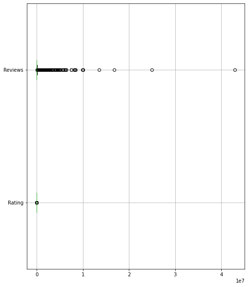

```python
plt.figure(figsize=(8,10))
apps.boxplot(vert=0)
```

```python
def fix_outlier(col):
 sorted(col)
 Q1,Q3=np.percentile(col,[25,75])
 IQR=Q3-Q1
 lower_range=Q1-(1.5*IQR)
 upper_range=Q3+(1.5*IQR)
 return lower_range,upper_range
```

```python
for c in ['Reviews']:
    lr,ur=fix_outlier(apps[c])
    apps[c]=np.where(apps[c]>ur,ur,apps[c])
    apps[c]=np.where(apps[c]<lr,lr,apps[c])
```

## g. Name the top 5 apps which have the highest number of reviews and their genre?

The top 5 apps as ordered by reviews are:

```python
df = apps[['App','Reviews', 'Genres']]
df.nlargest(5, 'Reviews')
```

|  | App | Reviews | Genres |
| --- | --- | --- | --- |
| 2 | U Launcher Lite – FREE Live Cool Themes, Hide ... | 45669.625 | Art & Design |
| 3 | Sketch - Draw & Paint | 45669.625 | Art & Design |
| 18 | FlipaClip - Cartoon animation | 45669.625 | Art & Design |
| 19 | ibis Paint X | 45669.625 | Art & Design |
| 45 | Canva: Poster, banner, card maker & graphic de... | 45669.625 | Art & Design |

## h. Make the values of ‘Size’ as integers by replacing M and K with correct values. Convert all the values to numeric and make invalid values to NaN.

```python
def change_size(size):
    if 'M' in size:
        x = size[:-1]
        x = float(x)*1000000
        return(x)
    elif 'k' == size[-1:]:
        x = size[:-1]
        x = float(x)*1000
        return(x)
    else:
        return None

apps["Size"] = apps["Size"].map(change_size)
```

```python
apps.Size.fillna(method = 'ffill', inplace = True)
```

```python
apps
```

|  | App | Category | Rating | Reviews | Size | Installs | Type | Price | Content Rating | Genres | Last Updated | Current Ver | Android Ver | Rating_cat |
| --- | --- | --- | --- | --- | --- | --- | --- | --- | --- | --- | --- | --- | --- | --- |
| 0 | Photo Editor & Candy Camera & Grid & ScrapBook | ART_AND_DESIGN | 4.1 | 159.000 | 19000000.0 | 10,000+ | Free | 0 | Everyone | Art & Design | January 7, 2018 | 1.0.0 | 4.0.3 and up | High |
| 2 | U Launcher Lite – FREE Live Cool Themes, Hide ... | ART_AND_DESIGN | 4.7 | 45669.625 | 8700000.0 | 5,000,000+ | Free | 0 | Everyone | Art & Design | August 1, 2018 | 1.2.4 | 4.0.3 and up | High |
| 3 | Sketch - Draw & Paint | ART_AND_DESIGN | 4.5 | 45669.625 | 25000000.0 | 50,000,000+ | Free | 0 | Teen | Art & Design | June 8, 2018 | Varies with device | 4.2 and up | High |
| 4 | Pixel Draw - Number Art Coloring Book | ART_AND_DESIGN | 4.3 | 967.000 | 2800000.0 | 100,000+ | Free | 0 | Everyone | Art & Design;Creativity | June 20, 2018 | 1.1 | 4.4 and up | High |
| 5 | Paper flowers instructions | ART_AND_DESIGN | 4.4 | 167.000 | 5600000.0 | 50,000+ | Free | 0 | Everyone | Art & Design | March 26, 2017 | 1.0 | 2.3 and up | High |
| ... | ... | ... | ... | ... | ... | ... | ... | ... | ... | ... | ... | ... | ... | ... |
| 10836 | Sya9a Maroc - FR | FAMILY | 4.5 | 38.000 | 53000000.0 | 5,000+ | Free | 0 | Everyone | Education | July 25, 2017 | 1.48 | 4.1 and up | High |
| 10837 | Fr. Mike Schmitz Audio Teachings | FAMILY | 5.0 | 4.000 | 3600000.0 | 100+ | Free | 0 | Everyone | Education | July 6, 2018 | 1.0 | 4.1 and up | High |
| 10838 | Parkinson Exercices FR | MEDICAL | 4.3 | 3.000 | 9500000.0 | 1,000+ | Free | 0 | Everyone | Medical | January 20, 2017 | 1.0 | 2.2 and up | High |
| 10839 | The SCP Foundation DB fr nn5n | BOOKS_AND_REFERENCE | 4.5 | 114.000 | 9500000.0 | 1,000+ | Free | 0 | Mature 17+ | Books & Reference | January 19, 2015 | Varies with device | Varies with device | High |
| 10840 | iHoroscope - 2018 Daily Horoscope & Astrology | LIFESTYLE | 4.5 | 45669.625 | 19000000.0 | 10,000,000+ | Free | 0 | Everyone | Lifestyle | July 25, 2018 | Varies with device | Varies with device | High |

8862 rows × 14 columns

```python
apps.isnull().sum()
```

```
App               0
Category          0
Rating            0
Reviews           0
Size              0
Installs          0
Type              1
Price             0
Content Rating    0
Genres            1
Last Updated      0
Current Ver       8
Android Ver       2
Rating_cat        0
dtype: int64
```

## i. Remove “,” and “+” from the values of the “Installs” column and change the datatype.

```python
apps["Installs"] = apps.Installs.apply(lambda x: str(x).replace("+",""))
apps["Installs"] = apps.Installs.apply(lambda x: str(x).replace(",",""))
apps["Installs"] = apps.Installs.apply(lambda x: float(x))
apps.Installs.dtype
```

```
dtype('float64')
```

```python
apps.isnull().sum()
```

```
App               0
Category          0
Rating            0
Reviews           0
Size              0
Installs          0
Type              1
Price             0
Content Rating    0
Genres            1
Last Updated      0
Current Ver       8
Android Ver       2
Rating_cat        0
dtype: int64
```

As we are about to drop Current version Android version and Genres column we don't need to fix their null values hence we fix the type column and continue with our process

## j. What is the percentage of paid apps in the data?

```python
apps['Type'] = apps['Type'].replace([np.nan],'Free')
```

```python
apps.isnull().sum()
```

```
App               0
Category          0
Rating            0
Reviews           0
Size              0
Installs          0
Type              0
Price             0
Content Rating    0
Genres            1
Last Updated      0
Current Ver       8
Android Ver       2
Rating_cat        0
dtype: int64
```

```python
print('Percentage of', "\n \n" ,apps.Type.value_counts()/ df.shape[0] * 100.00)
```

```
Percentage of

 Free    91.943128
Paid     8.056872
Name: Type, dtype: float64
```

## k. Remove the " Dollar" sign the “Price” column values and make it a numerical column

```python
apps.Price=apps.Price.apply(lambda x: x.strip('$'))
apps['Price'] = apps['Price'].astype(float)
```

"$" Removed from the column

```python
apps
```

|  | App | Category | Rating | Reviews | Size | Installs | Type | Price | Content Rating | Genres | Last Updated | Current Ver | Android Ver | Rating_cat |
| --- | --- | --- | --- | --- | --- | --- | --- | --- | --- | --- | --- | --- | --- | --- |
| 0 | Photo Editor & Candy Camera & Grid & ScrapBook | ART_AND_DESIGN | 4.1 | 159.000 | 19000000.0 | 10000.0 | Free | 0.0 | Everyone | Art & Design | January 7, 2018 | 1.0.0 | 4.0.3 and up | High |
| 2 | U Launcher Lite – FREE Live Cool Themes, Hide ... | ART_AND_DESIGN | 4.7 | 45669.625 | 8700000.0 | 5000000.0 | Free | 0.0 | Everyone | Art & Design | August 1, 2018 | 1.2.4 | 4.0.3 and up | High |
| 3 | Sketch - Draw & Paint | ART_AND_DESIGN | 4.5 | 45669.625 | 25000000.0 | 50000000.0 | Free | 0.0 | Teen | Art & Design | June 8, 2018 | Varies with device | 4.2 and up | High |
| 4 | Pixel Draw - Number Art Coloring Book | ART_AND_DESIGN | 4.3 | 967.000 | 2800000.0 | 100000.0 | Free | 0.0 | Everyone | Art & Design;Creativity | June 20, 2018 | 1.1 | 4.4 and up | High |
| 5 | Paper flowers instructions | ART_AND_DESIGN | 4.4 | 167.000 | 5600000.0 | 50000.0 | Free | 0.0 | Everyone | Art & Design | March 26, 2017 | 1.0 | 2.3 and up | High |
| ... | ... | ... | ... | ... | ... | ... | ... | ... | ... | ... | ... | ... | ... | ... |
| 10836 | Sya9a Maroc - FR | FAMILY | 4.5 | 38.000 | 53000000.0 | 5000.0 | Free | 0.0 | Everyone | Education | July 25, 2017 | 1.48 | 4.1 and up | High |
| 10837 | Fr. Mike Schmitz Audio Teachings | FAMILY | 5.0 | 4.000 | 3600000.0 | 100.0 | Free | 0.0 | Everyone | Education | July 6, 2018 | 1.0 | 4.1 and up | High |
| 10838 | Parkinson Exercices FR | MEDICAL | 4.3 | 3.000 | 9500000.0 | 1000.0 | Free | 0.0 | Everyone | Medical | January 20, 2017 | 1.0 | 2.2 and up | High |
| 10839 | The SCP Foundation DB fr nn5n | BOOKS_AND_REFERENCE | 4.5 | 114.000 | 9500000.0 | 1000.0 | Free | 0.0 | Mature 17+ | Books & Reference | January 19, 2015 | Varies with device | Varies with device | High |
| 10840 | iHoroscope - 2018 Daily Horoscope & Astrology | LIFESTYLE | 4.5 | 45669.625 | 19000000.0 | 10000000.0 | Free | 0.0 | Everyone | Lifestyle | July 25, 2018 | Varies with device | Varies with device | High |

8862 rows × 14 columns

### l. Which is the most expensive app and how much does it cost?

```python
apps.groupby('App')['Price'].max().sort_values(ascending=False).head(1)
```

```
App
I'm Rich - Trump Edition    400.0
Name: Price, dtype: float64
```

The most expenssive app is I'm Rich - Trump Edition amd it costs $400.0

### m. Drop columns that you feel can not be used for model building. ExampleApp, Content Rating, Genre, Last updated, Current Ver, and Android Ver columns from the final data frame.

```python
apps.drop(labels = ['Last Updated','Current Ver','Android Ver','App','Genres','Content Rating' ], axis = 1, inplace = True)
```

### n. Encode categorical column (Type, Rating_categories, Category)

```python
apps_2 = pd.get_dummies(apps['Category'],prefix_sep='_',prefix='Category')
apps = apps.join(apps_2)
```

```python
apps_2 = pd.get_dummies(apps['Type'])
apps = apps.join(apps_2)
```

```python
apps_2 = pd.get_dummies(apps['Rating_cat'])
apps = apps.join(apps_2)
```

Encoding the categorial columns

```python
apps.T
```

|  | 0 | 2 | 3 | 4 | 5 | 6 | 7 | 8 | 9 | 10 | ... | 10831 | 10832 | 10833 | 10834 | 10835 | 10836 | 10837 | 10838 | 10839 | 10840 |
| --- | --- | --- | --- | --- | --- | --- | --- | --- | --- | --- | --- | --- | --- | --- | --- | --- | --- | --- | --- | --- | --- |
| Category | ART_AND_DESIGN | ART_AND_DESIGN | ART_AND_DESIGN | ART_AND_DESIGN | ART_AND_DESIGN | ART_AND_DESIGN | ART_AND_DESIGN | ART_AND_DESIGN | ART_AND_DESIGN | ART_AND_DESIGN | ... | MAPS_AND_NAVIGATION | WEATHER | BOOKS_AND_REFERENCE | FAMILY | BUSINESS | FAMILY | FAMILY | MEDICAL | BOOKS_AND_REFERENCE | LIFESTYLE |
| Rating | 4.1 | 4.7 | 4.5 | 4.3 | 4.4 | 3.8 | 4.1 | 4.4 | 4.7 | 4.4 | ... | 4.3 | 3.8 | 4.8 | 4.0 | 4.3 | 4.5 | 5.0 | 4.3 | 4.5 | 4.5 |
| Reviews | 159.0 | 45669.625 | 45669.625 | 967.0 | 167.0 | 178.0 | 36815.0 | 13791.0 | 121.0 | 13880.0 | ... | 38.0 | 1195.0 | 44.0 | 7.0 | 0.0 | 38.0 | 4.0 | 3.0 | 114.0 | 45669.625 |
| Size | 19000000.0 | 8700000.0 | 25000000.0 | 2800000.0 | 5600000.0 | 19000000.0 | 29000000.0 | 33000000.0 | 3100000.0 | 28000000.0 | ... | 9800000.0 | 582000.0 | 619000.0 | 2600000.0 | 9600000.0 | 53000000.0 | 3600000.0 | 9500000.0 | 9500000.0 | 19000000.0 |
| Installs | 10000.0 | 5000000.0 | 50000000.0 | 100000.0 | 50000.0 | 50000.0 | 1000000.0 | 1000000.0 | 10000.0 | 1000000.0 | ... | 5000.0 | 100000.0 | 1000.0 | 500.0 | 10.0 | 5000.0 | 100.0 | 1000.0 | 1000.0 | 10000000.0 |
| Type | Free | Free | Free | Free | Free | Free | Free | Free | Free | Free | ... | Free | Free | Free | Free | Free | Free | Free | Free | Free | Free |
| Price | 0.0 | 0.0 | 0.0 | 0.0 | 0.0 | 0.0 | 0.0 | 0.0 | 0.0 | 0.0 | ... | 0.0 | 0.0 | 0.0 | 0.0 | 0.0 | 0.0 | 0.0 | 0.0 | 0.0 | 0.0 |
| Rating_cat | High | High | High | High | High | High | High | High | High | High | ... | High | High | High | High | High | High | High | High | High | High |
| Category_ART_AND_DESIGN | 1 | 1 | 1 | 1 | 1 | 1 | 1 | 1 | 1 | 1 | ... | 0 | 0 | 0 | 0 | 0 | 0 | 0 | 0 | 0 | 0 |
| Category_AUTO_AND_VEHICLES | 0 | 0 | 0 | 0 | 0 | 0 | 0 | 0 | 0 | 0 | ... | 0 | 0 | 0 | 0 | 0 | 0 | 0 | 0 | 0 | 0 |
| Category_BEAUTY | 0 | 0 | 0 | 0 | 0 | 0 | 0 | 0 | 0 | 0 | ... | 0 | 0 | 0 | 0 | 0 | 0 | 0 | 0 | 0 | 0 |
| Category_BOOKS_AND_REFERENCE | 0 | 0 | 0 | 0 | 0 | 0 | 0 | 0 | 0 | 0 | ... | 0 | 0 | 1 | 0 | 0 | 0 | 0 | 0 | 1 | 0 |
| Category_BUSINESS | 0 | 0 | 0 | 0 | 0 | 0 | 0 | 0 | 0 | 0 | ... | 0 | 0 | 0 | 0 | 1 | 0 | 0 | 0 | 0 | 0 |
| Category_COMICS | 0 | 0 | 0 | 0 | 0 | 0 | 0 | 0 | 0 | 0 | ... | 0 | 0 | 0 | 0 | 0 | 0 | 0 | 0 | 0 | 0 |
| Category_COMMUNICATION | 0 | 0 | 0 | 0 | 0 | 0 | 0 | 0 | 0 | 0 | ... | 0 | 0 | 0 | 0 | 0 | 0 | 0 | 0 | 0 | 0 |
| Category_DATING | 0 | 0 | 0 | 0 | 0 | 0 | 0 | 0 | 0 | 0 | ... | 0 | 0 | 0 | 0 | 0 | 0 | 0 | 0 | 0 | 0 |
| Category_EDUCATION | 0 | 0 | 0 | 0 | 0 | 0 | 0 | 0 | 0 | 0 | ... | 0 | 0 | 0 | 0 | 0 | 0 | 0 | 0 | 0 | 0 |
| Category_ENTERTAINMENT | 0 | 0 | 0 | 0 | 0 | 0 | 0 | 0 | 0 | 0 | ... | 0 | 0 | 0 | 0 | 0 | 0 | 0 | 0 | 0 | 0 |
| Category_EVENTS | 0 | 0 | 0 | 0 | 0 | 0 | 0 | 0 | 0 | 0 | ... | 0 | 0 | 0 | 0 | 0 | 0 | 0 | 0 | 0 | 0 |
| Category_FAMILY | 0 | 0 | 0 | 0 | 0 | 0 | 0 | 0 | 0 | 0 | ... | 0 | 0 | 0 | 1 | 0 | 1 | 1 | 0 | 0 | 0 |
| Category_FINANCE | 0 | 0 | 0 | 0 | 0 | 0 | 0 | 0 | 0 | 0 | ... | 0 | 0 | 0 | 0 | 0 | 0 | 0 | 0 | 0 | 0 |
| Category_FOOD_AND_DRINK | 0 | 0 | 0 | 0 | 0 | 0 | 0 | 0 | 0 | 0 | ... | 0 | 0 | 0 | 0 | 0 | 0 | 0 | 0 | 0 | 0 |
| Category_GAME | 0 | 0 | 0 | 0 | 0 | 0 | 0 | 0 | 0 | 0 | ... | 0 | 0 | 0 | 0 | 0 | 0 | 0 | 0 | 0 | 0 |
| Category_HEALTH_AND_FITNESS | 0 | 0 | 0 | 0 | 0 | 0 | 0 | 0 | 0 | 0 | ... | 0 | 0 | 0 | 0 | 0 | 0 | 0 | 0 | 0 | 0 |
| Category_HOUSE_AND_HOME | 0 | 0 | 0 | 0 | 0 | 0 | 0 | 0 | 0 | 0 | ... | 0 | 0 | 0 | 0 | 0 | 0 | 0 | 0 | 0 | 0 |
| Category_LIBRARIES_AND_DEMO | 0 | 0 | 0 | 0 | 0 | 0 | 0 | 0 | 0 | 0 | ... | 0 | 0 | 0 | 0 | 0 | 0 | 0 | 0 | 0 | 0 |
| Category_LIFESTYLE | 0 | 0 | 0 | 0 | 0 | 0 | 0 | 0 | 0 | 0 | ... | 0 | 0 | 0 | 0 | 0 | 0 | 0 | 0 | 0 | 1 |
| Category_MAPS_AND_NAVIGATION | 0 | 0 | 0 | 0 | 0 | 0 | 0 | 0 | 0 | 0 | ... | 1 | 0 | 0 | 0 | 0 | 0 | 0 | 0 | 0 | 0 |
| Category_MEDICAL | 0 | 0 | 0 | 0 | 0 | 0 | 0 | 0 | 0 | 0 | ... | 0 | 0 | 0 | 0 | 0 | 0 | 0 | 1 | 0 | 0 |
| Category_NEWS_AND_MAGAZINES | 0 | 0 | 0 | 0 | 0 | 0 | 0 | 0 | 0 | 0 | ... | 0 | 0 | 0 | 0 | 0 | 0 | 0 | 0 | 0 | 0 |
| Category_PARENTING | 0 | 0 | 0 | 0 | 0 | 0 | 0 | 0 | 0 | 0 | ... | 0 | 0 | 0 | 0 | 0 | 0 | 0 | 0 | 0 | 0 |
| Category_PERSONALIZATION | 0 | 0 | 0 | 0 | 0 | 0 | 0 | 0 | 0 | 0 | ... | 0 | 0 | 0 | 0 | 0 | 0 | 0 | 0 | 0 | 0 |
| Category_PHOTOGRAPHY | 0 | 0 | 0 | 0 | 0 | 0 | 0 | 0 | 0 | 0 | ... | 0 | 0 | 0 | 0 | 0 | 0 | 0 | 0 | 0 | 0 |
| Category_PRODUCTIVITY | 0 | 0 | 0 | 0 | 0 | 0 | 0 | 0 | 0 | 0 | ... | 0 | 0 | 0 | 0 | 0 | 0 | 0 | 0 | 0 | 0 |
| Category_SHOPPING | 0 | 0 | 0 | 0 | 0 | 0 | 0 | 0 | 0 | 0 | ... | 0 | 0 | 0 | 0 | 0 | 0 | 0 | 0 | 0 | 0 |
| Category_SOCIAL | 0 | 0 | 0 | 0 | 0 | 0 | 0 | 0 | 0 | 0 | ... | 0 | 0 | 0 | 0 | 0 | 0 | 0 | 0 | 0 | 0 |
| Category_SPORTS | 0 | 0 | 0 | 0 | 0 | 0 | 0 | 0 | 0 | 0 | ... | 0 | 0 | 0 | 0 | 0 | 0 | 0 | 0 | 0 | 0 |
| Category_TOOLS | 0 | 0 | 0 | 0 | 0 | 0 | 0 | 0 | 0 | 0 | ... | 0 | 0 | 0 | 0 | 0 | 0 | 0 | 0 | 0 | 0 |
| Category_TRAVEL_AND_LOCAL | 0 | 0 | 0 | 0 | 0 | 0 | 0 | 0 | 0 | 0 | ... | 0 | 0 | 0 | 0 | 0 | 0 | 0 | 0 | 0 | 0 |
| Category_VIDEO_PLAYERS | 0 | 0 | 0 | 0 | 0 | 0 | 0 | 0 | 0 | 0 | ... | 0 | 0 | 0 | 0 | 0 | 0 | 0 | 0 | 0 | 0 |
| Category_WEATHER | 0 | 0 | 0 | 0 | 0 | 0 | 0 | 0 | 0 | 0 | ... | 0 | 1 | 0 | 0 | 0 | 0 | 0 | 0 | 0 | 0 |
| Free | 1 | 1 | 1 | 1 | 1 | 1 | 1 | 1 | 1 | 1 | ... | 1 | 1 | 1 | 1 | 1 | 1 | 1 | 1 | 1 | 1 |
| Paid | 0 | 0 | 0 | 0 | 0 | 0 | 0 | 0 | 0 | 0 | ... | 0 | 0 | 0 | 0 | 0 | 0 | 0 | 0 | 0 | 0 |
| High | 1 | 1 | 1 | 1 | 1 | 1 | 1 | 1 | 1 | 1 | ... | 1 | 1 | 1 | 1 | 1 | 1 | 1 | 1 | 1 | 1 |
| Low | 0 | 0 | 0 | 0 | 0 | 0 | 0 | 0 | 0 | 0 | ... | 0 | 0 | 0 | 0 | 0 | 0 | 0 | 0 | 0 | 0 |

45 rows × 8862 columns

```python
apps.drop(labels=['Rating', 'Type', 'Category'],axis=1,inplace=True)
```

Dropping encoded columns

```python
apps.T
```

|  | 0 | 2 | 3 | 4 | 5 | 6 | 7 | 8 | 9 | 10 | ... | 10831 | 10832 | 10833 | 10834 | 10835 | 10836 | 10837 | 10838 | 10839 | 10840 |
| --- | --- | --- | --- | --- | --- | --- | --- | --- | --- | --- | --- | --- | --- | --- | --- | --- | --- | --- | --- | --- | --- |
| Reviews | 159.0 | 45669.625 | 45669.625 | 967.0 | 167.0 | 178.0 | 36815.0 | 13791.0 | 121.0 | 13880.0 | ... | 38.0 | 1195.0 | 44.0 | 7.0 | 0.0 | 38.0 | 4.0 | 3.0 | 114.0 | 45669.625 |
| Size | 19000000.0 | 8700000.0 | 25000000.0 | 2800000.0 | 5600000.0 | 19000000.0 | 29000000.0 | 33000000.0 | 3100000.0 | 28000000.0 | ... | 9800000.0 | 582000.0 | 619000.0 | 2600000.0 | 9600000.0 | 53000000.0 | 3600000.0 | 9500000.0 | 9500000.0 | 19000000.0 |
| Installs | 10000.0 | 5000000.0 | 50000000.0 | 100000.0 | 50000.0 | 50000.0 | 1000000.0 | 1000000.0 | 10000.0 | 1000000.0 | ... | 5000.0 | 100000.0 | 1000.0 | 500.0 | 10.0 | 5000.0 | 100.0 | 1000.0 | 1000.0 | 10000000.0 |
| Price | 0.0 | 0.0 | 0.0 | 0.0 | 0.0 | 0.0 | 0.0 | 0.0 | 0.0 | 0.0 | ... | 0.0 | 0.0 | 0.0 | 0.0 | 0.0 | 0.0 | 0.0 | 0.0 | 0.0 | 0.0 |
| Rating_cat | High | High | High | High | High | High | High | High | High | High | ... | High | High | High | High | High | High | High | High | High | High |
| Category_ART_AND_DESIGN | 1 | 1 | 1 | 1 | 1 | 1 | 1 | 1 | 1 | 1 | ... | 0 | 0 | 0 | 0 | 0 | 0 | 0 | 0 | 0 | 0 |
| Category_AUTO_AND_VEHICLES | 0 | 0 | 0 | 0 | 0 | 0 | 0 | 0 | 0 | 0 | ... | 0 | 0 | 0 | 0 | 0 | 0 | 0 | 0 | 0 | 0 |
| Category_BEAUTY | 0 | 0 | 0 | 0 | 0 | 0 | 0 | 0 | 0 | 0 | ... | 0 | 0 | 0 | 0 | 0 | 0 | 0 | 0 | 0 | 0 |
| Category_BOOKS_AND_REFERENCE | 0 | 0 | 0 | 0 | 0 | 0 | 0 | 0 | 0 | 0 | ... | 0 | 0 | 1 | 0 | 0 | 0 | 0 | 0 | 1 | 0 |
| Category_BUSINESS | 0 | 0 | 0 | 0 | 0 | 0 | 0 | 0 | 0 | 0 | ... | 0 | 0 | 0 | 0 | 1 | 0 | 0 | 0 | 0 | 0 |
| Category_COMICS | 0 | 0 | 0 | 0 | 0 | 0 | 0 | 0 | 0 | 0 | ... | 0 | 0 | 0 | 0 | 0 | 0 | 0 | 0 | 0 | 0 |
| Category_COMMUNICATION | 0 | 0 | 0 | 0 | 0 | 0 | 0 | 0 | 0 | 0 | ... | 0 | 0 | 0 | 0 | 0 | 0 | 0 | 0 | 0 | 0 |
| Category_DATING | 0 | 0 | 0 | 0 | 0 | 0 | 0 | 0 | 0 | 0 | ... | 0 | 0 | 0 | 0 | 0 | 0 | 0 | 0 | 0 | 0 |
| Category_EDUCATION | 0 | 0 | 0 | 0 | 0 | 0 | 0 | 0 | 0 | 0 | ... | 0 | 0 | 0 | 0 | 0 | 0 | 0 | 0 | 0 | 0 |
| Category_ENTERTAINMENT | 0 | 0 | 0 | 0 | 0 | 0 | 0 | 0 | 0 | 0 | ... | 0 | 0 | 0 | 0 | 0 | 0 | 0 | 0 | 0 | 0 |
| Category_EVENTS | 0 | 0 | 0 | 0 | 0 | 0 | 0 | 0 | 0 | 0 | ... | 0 | 0 | 0 | 0 | 0 | 0 | 0 | 0 | 0 | 0 |
| Category_FAMILY | 0 | 0 | 0 | 0 | 0 | 0 | 0 | 0 | 0 | 0 | ... | 0 | 0 | 0 | 1 | 0 | 1 | 1 | 0 | 0 | 0 |
| Category_FINANCE | 0 | 0 | 0 | 0 | 0 | 0 | 0 | 0 | 0 | 0 | ... | 0 | 0 | 0 | 0 | 0 | 0 | 0 | 0 | 0 | 0 |
| Category_FOOD_AND_DRINK | 0 | 0 | 0 | 0 | 0 | 0 | 0 | 0 | 0 | 0 | ... | 0 | 0 | 0 | 0 | 0 | 0 | 0 | 0 | 0 | 0 |
| Category_GAME | 0 | 0 | 0 | 0 | 0 | 0 | 0 | 0 | 0 | 0 | ... | 0 | 0 | 0 | 0 | 0 | 0 | 0 | 0 | 0 | 0 |
| Category_HEALTH_AND_FITNESS | 0 | 0 | 0 | 0 | 0 | 0 | 0 | 0 | 0 | 0 | ... | 0 | 0 | 0 | 0 | 0 | 0 | 0 | 0 | 0 | 0 |
| Category_HOUSE_AND_HOME | 0 | 0 | 0 | 0 | 0 | 0 | 0 | 0 | 0 | 0 | ... | 0 | 0 | 0 | 0 | 0 | 0 | 0 | 0 | 0 | 0 |
| Category_LIBRARIES_AND_DEMO | 0 | 0 | 0 | 0 | 0 | 0 | 0 | 0 | 0 | 0 | ... | 0 | 0 | 0 | 0 | 0 | 0 | 0 | 0 | 0 | 0 |
| Category_LIFESTYLE | 0 | 0 | 0 | 0 | 0 | 0 | 0 | 0 | 0 | 0 | ... | 0 | 0 | 0 | 0 | 0 | 0 | 0 | 0 | 0 | 1 |
| Category_MAPS_AND_NAVIGATION | 0 | 0 | 0 | 0 | 0 | 0 | 0 | 0 | 0 | 0 | ... | 1 | 0 | 0 | 0 | 0 | 0 | 0 | 0 | 0 | 0 |
| Category_MEDICAL | 0 | 0 | 0 | 0 | 0 | 0 | 0 | 0 | 0 | 0 | ... | 0 | 0 | 0 | 0 | 0 | 0 | 0 | 1 | 0 | 0 |
| Category_NEWS_AND_MAGAZINES | 0 | 0 | 0 | 0 | 0 | 0 | 0 | 0 | 0 | 0 | ... | 0 | 0 | 0 | 0 | 0 | 0 | 0 | 0 | 0 | 0 |
| Category_PARENTING | 0 | 0 | 0 | 0 | 0 | 0 | 0 | 0 | 0 | 0 | ... | 0 | 0 | 0 | 0 | 0 | 0 | 0 | 0 | 0 | 0 |
| Category_PERSONALIZATION | 0 | 0 | 0 | 0 | 0 | 0 | 0 | 0 | 0 | 0 | ... | 0 | 0 | 0 | 0 | 0 | 0 | 0 | 0 | 0 | 0 |
| Category_PHOTOGRAPHY | 0 | 0 | 0 | 0 | 0 | 0 | 0 | 0 | 0 | 0 | ... | 0 | 0 | 0 | 0 | 0 | 0 | 0 | 0 | 0 | 0 |
| Category_PRODUCTIVITY | 0 | 0 | 0 | 0 | 0 | 0 | 0 | 0 | 0 | 0 | ... | 0 | 0 | 0 | 0 | 0 | 0 | 0 | 0 | 0 | 0 |
| Category_SHOPPING | 0 | 0 | 0 | 0 | 0 | 0 | 0 | 0 | 0 | 0 | ... | 0 | 0 | 0 | 0 | 0 | 0 | 0 | 0 | 0 | 0 |
| Category_SOCIAL | 0 | 0 | 0 | 0 | 0 | 0 | 0 | 0 | 0 | 0 | ... | 0 | 0 | 0 | 0 | 0 | 0 | 0 | 0 | 0 | 0 |
| Category_SPORTS | 0 | 0 | 0 | 0 | 0 | 0 | 0 | 0 | 0 | 0 | ... | 0 | 0 | 0 | 0 | 0 | 0 | 0 | 0 | 0 | 0 |
| Category_TOOLS | 0 | 0 | 0 | 0 | 0 | 0 | 0 | 0 | 0 | 0 | ... | 0 | 0 | 0 | 0 | 0 | 0 | 0 | 0 | 0 | 0 |
| Category_TRAVEL_AND_LOCAL | 0 | 0 | 0 | 0 | 0 | 0 | 0 | 0 | 0 | 0 | ... | 0 | 0 | 0 | 0 | 0 | 0 | 0 | 0 | 0 | 0 |
| Category_VIDEO_PLAYERS | 0 | 0 | 0 | 0 | 0 | 0 | 0 | 0 | 0 | 0 | ... | 0 | 0 | 0 | 0 | 0 | 0 | 0 | 0 | 0 | 0 |
| Category_WEATHER | 0 | 0 | 0 | 0 | 0 | 0 | 0 | 0 | 0 | 0 | ... | 0 | 1 | 0 | 0 | 0 | 0 | 0 | 0 | 0 | 0 |
| Free | 1 | 1 | 1 | 1 | 1 | 1 | 1 | 1 | 1 | 1 | ... | 1 | 1 | 1 | 1 | 1 | 1 | 1 | 1 | 1 | 1 |
| Paid | 0 | 0 | 0 | 0 | 0 | 0 | 0 | 0 | 0 | 0 | ... | 0 | 0 | 0 | 0 | 0 | 0 | 0 | 0 | 0 | 0 |
| High | 1 | 1 | 1 | 1 | 1 | 1 | 1 | 1 | 1 | 1 | ... | 1 | 1 | 1 | 1 | 1 | 1 | 1 | 1 | 1 | 1 |
| Low | 0 | 0 | 0 | 0 | 0 | 0 | 0 | 0 | 0 | 0 | ... | 0 | 0 | 0 | 0 | 0 | 0 | 0 | 0 | 0 | 0 |

42 rows × 8862 columns

# 3. Prepare data for modeling.

## a. Segregate dependent variable and independent features into two separatevariables and split the data into train and test set [ Use 70:30 split ]

```python
x = apps.drop(labels = ['Rating_cat', 'High', 'Low'],axis = 1)

y = apps['Rating_cat']
```

The Independent Variable

```python
x.T
```

|  | 0 | 2 | 3 | 4 | 5 | 6 | 7 | 8 | 9 | 10 | ... | 10831 | 10832 | 10833 | 10834 | 10835 | 10836 | 10837 | 10838 | 10839 | 10840 |
| --- | --- | --- | --- | --- | --- | --- | --- | --- | --- | --- | --- | --- | --- | --- | --- | --- | --- | --- | --- | --- | --- |
| Reviews | 159.0 | 45669.625 | 4.566962e+04 | 967.0 | 167.0 | 178.0 | 36815.0 | 13791.0 | 121.0 | 13880.0 | ... | 38.0 | 1195.0 | 44.0 | 7.0 | 0.0 | 38.0 | 4.0 | 3.0 | 114.0 | 4.566962e+04 |
| Size | 19000000.0 | 8700000.000 | 2.500000e+07 | 2800000.0 | 5600000.0 | 19000000.0 | 29000000.0 | 33000000.0 | 3100000.0 | 28000000.0 | ... | 9800000.0 | 582000.0 | 619000.0 | 2600000.0 | 9600000.0 | 53000000.0 | 3600000.0 | 9500000.0 | 9500000.0 | 1.900000e+07 |
| Installs | 10000.0 | 5000000.000 | 5.000000e+07 | 100000.0 | 50000.0 | 50000.0 | 1000000.0 | 1000000.0 | 10000.0 | 1000000.0 | ... | 5000.0 | 100000.0 | 1000.0 | 500.0 | 10.0 | 5000.0 | 100.0 | 1000.0 | 1000.0 | 1.000000e+07 |
| Price | 0.0 | 0.000 | 0.000000e+00 | 0.0 | 0.0 | 0.0 | 0.0 | 0.0 | 0.0 | 0.0 | ... | 0.0 | 0.0 | 0.0 | 0.0 | 0.0 | 0.0 | 0.0 | 0.0 | 0.0 | 0.000000e+00 |
| Category_ART_AND_DESIGN | 1.0 | 1.000 | 1.000000e+00 | 1.0 | 1.0 | 1.0 | 1.0 | 1.0 | 1.0 | 1.0 | ... | 0.0 | 0.0 | 0.0 | 0.0 | 0.0 | 0.0 | 0.0 | 0.0 | 0.0 | 0.000000e+00 |
| Category_AUTO_AND_VEHICLES | 0.0 | 0.000 | 0.000000e+00 | 0.0 | 0.0 | 0.0 | 0.0 | 0.0 | 0.0 | 0.0 | ... | 0.0 | 0.0 | 0.0 | 0.0 | 0.0 | 0.0 | 0.0 | 0.0 | 0.0 | 0.000000e+00 |
| Category_BEAUTY | 0.0 | 0.000 | 0.000000e+00 | 0.0 | 0.0 | 0.0 | 0.0 | 0.0 | 0.0 | 0.0 | ... | 0.0 | 0.0 | 0.0 | 0.0 | 0.0 | 0.0 | 0.0 | 0.0 | 0.0 | 0.000000e+00 |
| Category_BOOKS_AND_REFERENCE | 0.0 | 0.000 | 0.000000e+00 | 0.0 | 0.0 | 0.0 | 0.0 | 0.0 | 0.0 | 0.0 | ... | 0.0 | 0.0 | 1.0 | 0.0 | 0.0 | 0.0 | 0.0 | 0.0 | 1.0 | 0.000000e+00 |
| Category_BUSINESS | 0.0 | 0.000 | 0.000000e+00 | 0.0 | 0.0 | 0.0 | 0.0 | 0.0 | 0.0 | 0.0 | ... | 0.0 | 0.0 | 0.0 | 0.0 | 1.0 | 0.0 | 0.0 | 0.0 | 0.0 | 0.000000e+00 |
| Category_COMICS | 0.0 | 0.000 | 0.000000e+00 | 0.0 | 0.0 | 0.0 | 0.0 | 0.0 | 0.0 | 0.0 | ... | 0.0 | 0.0 | 0.0 | 0.0 | 0.0 | 0.0 | 0.0 | 0.0 | 0.0 | 0.000000e+00 |
| Category_COMMUNICATION | 0.0 | 0.000 | 0.000000e+00 | 0.0 | 0.0 | 0.0 | 0.0 | 0.0 | 0.0 | 0.0 | ... | 0.0 | 0.0 | 0.0 | 0.0 | 0.0 | 0.0 | 0.0 | 0.0 | 0.0 | 0.000000e+00 |
| Category_DATING | 0.0 | 0.000 | 0.000000e+00 | 0.0 | 0.0 | 0.0 | 0.0 | 0.0 | 0.0 | 0.0 | ... | 0.0 | 0.0 | 0.0 | 0.0 | 0.0 | 0.0 | 0.0 | 0.0 | 0.0 | 0.000000e+00 |
| Category_EDUCATION | 0.0 | 0.000 | 0.000000e+00 | 0.0 | 0.0 | 0.0 | 0.0 | 0.0 | 0.0 | 0.0 | ... | 0.0 | 0.0 | 0.0 | 0.0 | 0.0 | 0.0 | 0.0 | 0.0 | 0.0 | 0.000000e+00 |
| Category_ENTERTAINMENT | 0.0 | 0.000 | 0.000000e+00 | 0.0 | 0.0 | 0.0 | 0.0 | 0.0 | 0.0 | 0.0 | ... | 0.0 | 0.0 | 0.0 | 0.0 | 0.0 | 0.0 | 0.0 | 0.0 | 0.0 | 0.000000e+00 |
| Category_EVENTS | 0.0 | 0.000 | 0.000000e+00 | 0.0 | 0.0 | 0.0 | 0.0 | 0.0 | 0.0 | 0.0 | ... | 0.0 | 0.0 | 0.0 | 0.0 | 0.0 | 0.0 | 0.0 | 0.0 | 0.0 | 0.000000e+00 |
| Category_FAMILY | 0.0 | 0.000 | 0.000000e+00 | 0.0 | 0.0 | 0.0 | 0.0 | 0.0 | 0.0 | 0.0 | ... | 0.0 | 0.0 | 0.0 | 1.0 | 0.0 | 1.0 | 1.0 | 0.0 | 0.0 | 0.000000e+00 |
| Category_FINANCE | 0.0 | 0.000 | 0.000000e+00 | 0.0 | 0.0 | 0.0 | 0.0 | 0.0 | 0.0 | 0.0 | ... | 0.0 | 0.0 | 0.0 | 0.0 | 0.0 | 0.0 | 0.0 | 0.0 | 0.0 | 0.000000e+00 |
| Category_FOOD_AND_DRINK | 0.0 | 0.000 | 0.000000e+00 | 0.0 | 0.0 | 0.0 | 0.0 | 0.0 | 0.0 | 0.0 | ... | 0.0 | 0.0 | 0.0 | 0.0 | 0.0 | 0.0 | 0.0 | 0.0 | 0.0 | 0.000000e+00 |
| Category_GAME | 0.0 | 0.000 | 0.000000e+00 | 0.0 | 0.0 | 0.0 | 0.0 | 0.0 | 0.0 | 0.0 | ... | 0.0 | 0.0 | 0.0 | 0.0 | 0.0 | 0.0 | 0.0 | 0.0 | 0.0 | 0.000000e+00 |
| Category_HEALTH_AND_FITNESS | 0.0 | 0.000 | 0.000000e+00 | 0.0 | 0.0 | 0.0 | 0.0 | 0.0 | 0.0 | 0.0 | ... | 0.0 | 0.0 | 0.0 | 0.0 | 0.0 | 0.0 | 0.0 | 0.0 | 0.0 | 0.000000e+00 |
| Category_HOUSE_AND_HOME | 0.0 | 0.000 | 0.000000e+00 | 0.0 | 0.0 | 0.0 | 0.0 | 0.0 | 0.0 | 0.0 | ... | 0.0 | 0.0 | 0.0 | 0.0 | 0.0 | 0.0 | 0.0 | 0.0 | 0.0 | 0.000000e+00 |
| Category_LIBRARIES_AND_DEMO | 0.0 | 0.000 | 0.000000e+00 | 0.0 | 0.0 | 0.0 | 0.0 | 0.0 | 0.0 | 0.0 | ... | 0.0 | 0.0 | 0.0 | 0.0 | 0.0 | 0.0 | 0.0 | 0.0 | 0.0 | 0.000000e+00 |
| Category_LIFESTYLE | 0.0 | 0.000 | 0.000000e+00 | 0.0 | 0.0 | 0.0 | 0.0 | 0.0 | 0.0 | 0.0 | ... | 0.0 | 0.0 | 0.0 | 0.0 | 0.0 | 0.0 | 0.0 | 0.0 | 0.0 | 1.000000e+00 |
| Category_MAPS_AND_NAVIGATION | 0.0 | 0.000 | 0.000000e+00 | 0.0 | 0.0 | 0.0 | 0.0 | 0.0 | 0.0 | 0.0 | ... | 1.0 | 0.0 | 0.0 | 0.0 | 0.0 | 0.0 | 0.0 | 0.0 | 0.0 | 0.000000e+00 |
| Category_MEDICAL | 0.0 | 0.000 | 0.000000e+00 | 0.0 | 0.0 | 0.0 | 0.0 | 0.0 | 0.0 | 0.0 | ... | 0.0 | 0.0 | 0.0 | 0.0 | 0.0 | 0.0 | 0.0 | 1.0 | 0.0 | 0.000000e+00 |
| Category_NEWS_AND_MAGAZINES | 0.0 | 0.000 | 0.000000e+00 | 0.0 | 0.0 | 0.0 | 0.0 | 0.0 | 0.0 | 0.0 | ... | 0.0 | 0.0 | 0.0 | 0.0 | 0.0 | 0.0 | 0.0 | 0.0 | 0.0 | 0.000000e+00 |
| Category_PARENTING | 0.0 | 0.000 | 0.000000e+00 | 0.0 | 0.0 | 0.0 | 0.0 | 0.0 | 0.0 | 0.0 | ... | 0.0 | 0.0 | 0.0 | 0.0 | 0.0 | 0.0 | 0.0 | 0.0 | 0.0 | 0.000000e+00 |
| Category_PERSONALIZATION | 0.0 | 0.000 | 0.000000e+00 | 0.0 | 0.0 | 0.0 | 0.0 | 0.0 | 0.0 | 0.0 | ... | 0.0 | 0.0 | 0.0 | 0.0 | 0.0 | 0.0 | 0.0 | 0.0 | 0.0 | 0.000000e+00 |
| Category_PHOTOGRAPHY | 0.0 | 0.000 | 0.000000e+00 | 0.0 | 0.0 | 0.0 | 0.0 | 0.0 | 0.0 | 0.0 | ... | 0.0 | 0.0 | 0.0 | 0.0 | 0.0 | 0.0 | 0.0 | 0.0 | 0.0 | 0.000000e+00 |
| Category_PRODUCTIVITY | 0.0 | 0.000 | 0.000000e+00 | 0.0 | 0.0 | 0.0 | 0.0 | 0.0 | 0.0 | 0.0 | ... | 0.0 | 0.0 | 0.0 | 0.0 | 0.0 | 0.0 | 0.0 | 0.0 | 0.0 | 0.000000e+00 |
| Category_SHOPPING | 0.0 | 0.000 | 0.000000e+00 | 0.0 | 0.0 | 0.0 | 0.0 | 0.0 | 0.0 | 0.0 | ... | 0.0 | 0.0 | 0.0 | 0.0 | 0.0 | 0.0 | 0.0 | 0.0 | 0.0 | 0.000000e+00 |
| Category_SOCIAL | 0.0 | 0.000 | 0.000000e+00 | 0.0 | 0.0 | 0.0 | 0.0 | 0.0 | 0.0 | 0.0 | ... | 0.0 | 0.0 | 0.0 | 0.0 | 0.0 | 0.0 | 0.0 | 0.0 | 0.0 | 0.000000e+00 |
| Category_SPORTS | 0.0 | 0.000 | 0.000000e+00 | 0.0 | 0.0 | 0.0 | 0.0 | 0.0 | 0.0 | 0.0 | ... | 0.0 | 0.0 | 0.0 | 0.0 | 0.0 | 0.0 | 0.0 | 0.0 | 0.0 | 0.000000e+00 |
| Category_TOOLS | 0.0 | 0.000 | 0.000000e+00 | 0.0 | 0.0 | 0.0 | 0.0 | 0.0 | 0.0 | 0.0 | ... | 0.0 | 0.0 | 0.0 | 0.0 | 0.0 | 0.0 | 0.0 | 0.0 | 0.0 | 0.000000e+00 |
| Category_TRAVEL_AND_LOCAL | 0.0 | 0.000 | 0.000000e+00 | 0.0 | 0.0 | 0.0 | 0.0 | 0.0 | 0.0 | 0.0 | ... | 0.0 | 0.0 | 0.0 | 0.0 | 0.0 | 0.0 | 0.0 | 0.0 | 0.0 | 0.000000e+00 |
| Category_VIDEO_PLAYERS | 0.0 | 0.000 | 0.000000e+00 | 0.0 | 0.0 | 0.0 | 0.0 | 0.0 | 0.0 | 0.0 | ... | 0.0 | 0.0 | 0.0 | 0.0 | 0.0 | 0.0 | 0.0 | 0.0 | 0.0 | 0.000000e+00 |
| Category_WEATHER | 0.0 | 0.000 | 0.000000e+00 | 0.0 | 0.0 | 0.0 | 0.0 | 0.0 | 0.0 | 0.0 | ... | 0.0 | 1.0 | 0.0 | 0.0 | 0.0 | 0.0 | 0.0 | 0.0 | 0.0 | 0.000000e+00 |
| Free | 1.0 | 1.000 | 1.000000e+00 | 1.0 | 1.0 | 1.0 | 1.0 | 1.0 | 1.0 | 1.0 | ... | 1.0 | 1.0 | 1.0 | 1.0 | 1.0 | 1.0 | 1.0 | 1.0 | 1.0 | 1.000000e+00 |
| Paid | 0.0 | 0.000 | 0.000000e+00 | 0.0 | 0.0 | 0.0 | 0.0 | 0.0 | 0.0 | 0.0 | ... | 0.0 | 0.0 | 0.0 | 0.0 | 0.0 | 0.0 | 0.0 | 0.0 | 0.0 | 0.000000e+00 |

39 rows × 8862 columns

Dependent Varibale

```python
y
```

```
0        High
2        High
3        High
4        High
5        High
         ...
10836    High
10837    High
10838    High
10839    High
10840    High
Name: Rating_cat, Length: 8862, dtype: object
```

```python
X_train, X_test, y_train, y_test = train_test_split (x, y, test_size=0.3, random_state=42)
X_train.shape, X_test.shape, y_train.shape, y_test.shape
y_train.replace({'High':1, 'Low':0}, inplace=True)
y_test.replace({'High':1, 'Low':0}, inplace = True)
```

```python
print(X_train.shape)
print(X_test.shape)
print(y_train.shape)
print(y_test.shape)
```

```
(6203, 39)
(2659, 39)
(6203,)
(2659,)
```

### 4. Build a classifier model to predict the rating category (Rating_cat - high or low) using the following algorithm and make predictions on the test data. Evaluate the model and report your results.

#### a. Decision Tree Classifier

```python
DT_model = tree.DecisionTreeClassifier(max_depth=10,min_samples_split=75)
DT_model.fit(X_train, y_train)
```

```
DecisionTreeClassifier(max_depth=10, min_samples_split=75)
```

```python
y_train_predict=DT_model.predict(X_train)
model_score=DT_model.score(X_train,y_train)
print('Score = ', model_score, "\n")
print('Confusion Matrix',"\n",metrics.confusion_matrix(y_train,y_train_predict), "\n \n")
print('Classification Report:', "\n \n",metrics.classification_report(y_train,y_train_predict))
```

```
Score =  0.9229405126551669

Confusion Matrix
 [[  12  474]
 [   4 5713]]


Classification Report:

               precision    recall  f1-score   support

           0       0.75      0.02      0.05       486
           1       0.92      1.00      0.96      5717

    accuracy                           0.92      6203
   macro avg       0.84      0.51      0.50      6203
weighted avg       0.91      0.92      0.89      6203
```

```python
y_test_predict=DT_model.predict(X_test)
model_score=DT_model.score(X_test,y_test)
print('Score = ', model_score, "\n")
print('Confusion Matrix',"\n",metrics.confusion_matrix(y_test,y_test_predict), "\n \n")
print('Classification Report:', "\n \n",metrics.classification_report(y_test,y_test_predict))
```

```
Score =  0.9172621286197818

Confusion Matrix
 [[   1  218]
 [   2 2438]]


Classification Report:

               precision    recall  f1-score   support

           0       0.33      0.00      0.01       219
           1       0.92      1.00      0.96      2440

    accuracy                           0.92      2659
   macro avg       0.63      0.50      0.48      2659
weighted avg       0.87      0.92      0.88      2659
```

#### b. Random Forest model

```python
RF_model=RandomForestClassifier(n_estimators=101,max_depth=15,random_state=1,min_samples_split=25)
RF_model.fit(X_train,y_train)
```

```
RandomForestClassifier(max_depth=15, min_samples_split=25, n_estimators=101,
                       random_state=1)
```

```python
y_train_predict=RF_model.predict(X_train)
model_score=RF_model.score(X_train,y_train)
print('Score = ', model_score, "\n")
print('Confusion Matrix',"\n",metrics.confusion_matrix(y_train,y_train_predict), "\n \n")
print('Classification Report:', "\n \n",metrics.classification_report(y_train,y_train_predict))
```

```
Score =  0.9218120264388199

Confusion Matrix
 [[   1  485]
 [   0 5717]]


Classification Report:

               precision    recall  f1-score   support

           0       1.00      0.00      0.00       486
           1       0.92      1.00      0.96      5717

    accuracy                           0.92      6203
   macro avg       0.96      0.50      0.48      6203
weighted avg       0.93      0.92      0.88      6203
```

```python
y_test_predict=RF_model.predict(X_test)
model_score=RF_model.score(X_test,y_test)
print('Score = ', model_score, "\n")
print('Confusion Matrix',"\n",metrics.confusion_matrix(y_test,y_test_predict), "\n \n")
print('Classification Report:', "\n \n",metrics.classification_report(y_test,y_test_predict))
```

```
Score =  0.9176382098533283

Confusion Matrix
 [[   0  219]
 [   0 2440]]


Classification Report:

               precision    recall  f1-score   support

           0       0.00      0.00      0.00       219
           1       0.92      1.00      0.96      2440

    accuracy                           0.92      2659
   macro avg       0.46      0.50      0.48      2659
weighted avg       0.84      0.92      0.88      2659
```

#### c. Gradient Boosting model

```python
gbc1=GradientBoostingClassifier(n_estimators=101,max_depth=15,random_state=1,min_samples_split=25)
gbc1.fit(X_train,y_train)
```

```
GradientBoostingClassifier(max_depth=15, min_samples_split=25, n_estimators=101,
                           random_state=1)
```

```python
y_train_predict=gbc1.predict(X_train)
model_score=gbc1.score(X_train,y_train)
print('Score = ', model_score, "\n")
print('Confusion Matrix',"\n",metrics.confusion_matrix(y_train,y_train_predict), "\n \n")
print('Classification Report:', "\n \n",metrics.classification_report(y_train,y_train_predict))
```

```
Score =  0.9970981783008221

Confusion Matrix
 [[ 468   18]
 [   0 5717]]


Classification Report:

               precision    recall  f1-score   support

           0       1.00      0.96      0.98       486
           1       1.00      1.00      1.00      5717

    accuracy                           1.00      6203
   macro avg       1.00      0.98      0.99      6203
weighted avg       1.00      1.00      1.00      6203
```

```python
y_test_predict=gbc1.predict(X_test)
model_score=gbc1.score(X_test,y_test)
print('Score = ', model_score, "\n")
print('Confusion Matrix',"\n",metrics.confusion_matrix(y_test,y_test_predict), "\n \n")
print('Classification Report:', "\n \n",metrics.classification_report(y_test,y_test_predict))
```

```
Score =  0.9067318540804814

Confusion Matrix
 [[  17  202]
 [  46 2394]]


Classification Report:

               precision    recall  f1-score   support

           0       0.27      0.08      0.12       219
           1       0.92      0.98      0.95      2440

    accuracy                           0.91      2659
   macro avg       0.60      0.53      0.54      2659
weighted avg       0.87      0.91      0.88      2659
```

#### d. Stacking model

```python
estimators=[('Gradient Boosting',gbc1),('Random Forest',RF_model),('Decision Tree',DT_model)]
final_estimator=GradientBoostingClassifier(random_state=1,max_depth=5)
```

```python
stacking_estimator=StackingClassifier(estimators=estimators,final_estimator=final_estimator)
stacking_estimator.fit(X_train,y_train)
```

```
StackingClassifier(estimators=[('Gradient Boosting',
                                GradientBoostingClassifier(max_depth=15,
                                                           min_samples_split=25,
                                                           n_estimators=101,
                                                           random_state=1)),
                               ('Random Forest',
                                RandomForestClassifier(max_depth=15,
                                                       min_samples_split=25,
                                                       n_estimators=101,
                                                       random_state=1)),
                               ('Decision Tree',
                                DecisionTreeClassifier(max_depth=10,
                                                       min_samples_split=75))],
                   final_estimator=GradientBoostingClassifier(max_depth=5,
                                                              random_state=1))
```

```python
y_train_predict=stacking_estimator.predict(X_train)
model_score=gbc1.score(X_train,y_train)
print('Score = ', model_score, "\n")
print('Confusion Matrix',"\n",metrics.confusion_matrix(y_train,y_train_predict), "\n \n")
print('Classification Report:', "\n \n",metrics.classification_report(y_train,y_train_predict))
```

```
Score =  0.9970981783008221

Confusion Matrix
 [[  31  455]
 [  28 5689]]


Classification Report:

               precision    recall  f1-score   support

           0       0.53      0.06      0.11       486
           1       0.93      1.00      0.96      5717

    accuracy                           0.92      6203
   macro avg       0.73      0.53      0.54      6203
weighted avg       0.89      0.92      0.89      6203
```

```python
y_test_predict=stacking_estimator.predict(X_test)
model_score=stacking_estimator.score(X_test,y_test)
print('Score = ', model_score, "\n")
print('Confusion Matrix',"\n",metrics.confusion_matrix(y_test,y_test_predict), "\n \n")
print('Classification Report:', "\n \n",metrics.classification_report(y_test,y_test_predict))
```

```
Score =  0.9127491538172245

Confusion Matrix
 [[   3  216]
 [  16 2424]]


Classification Report:

               precision    recall  f1-score   support

           0       0.16      0.01      0.03       219
           1       0.92      0.99      0.95      2440

    accuracy                           0.91      2659
   macro avg       0.54      0.50      0.49      2659
weighted avg       0.86      0.91      0.88      2659
```

### Check the importance of different features by using model.feature*importances* function in Python

```python
pd.DataFrame(gbc1.feature_importances_,index=X_test.columns).sort_values(0,ascending=False)
```

|  | 0 |
| --- | --- |
| Reviews | 0.398469 |
| Size | 0.240916 |
| Installs | 0.073158 |
| Category_TOOLS | 0.016560 |
| Category_BUSINESS | 0.016036 |
| Category_FINANCE | 0.015666 |
| Price | 0.014423 |
| Category_LIFESTYLE | 0.013549 |
| Category_FAMILY | 0.013315 |
| Category_PRODUCTIVITY | 0.013135 |
| Category_VIDEO_PLAYERS | 0.012312 |
| Category_HEALTH_AND_FITNESS | 0.011767 |
| Category_PHOTOGRAPHY | 0.011524 |
| Category_DATING | 0.011263 |
| Category_SPORTS | 0.011062 |
| Category_MEDICAL | 0.010838 |
| Category_MAPS_AND_NAVIGATION | 0.010785 |
| Category_FOOD_AND_DRINK | 0.009326 |
| Category_NEWS_AND_MAGAZINES | 0.008998 |
| Category_GAME | 0.008901 |
| Category_COMMUNICATION | 0.008637 |
| Category_TRAVEL_AND_LOCAL | 0.008097 |
| Category_SHOPPING | 0.007710 |
| Category_SOCIAL | 0.007086 |
| Category_COMICS | 0.005604 |
| Category_AUTO_AND_VEHICLES | 0.005404 |
| Category_BOOKS_AND_REFERENCE | 0.004666 |
| Category_HOUSE_AND_HOME | 0.004612 |
| Category_PERSONALIZATION | 0.004594 |
| Category_ENTERTAINMENT | 0.004523 |
| Category_LIBRARIES_AND_DEMO | 0.003938 |
| Category_PARENTING | 0.003131 |
| Category_EVENTS | 0.002529 |
| Free | 0.001846 |
| Paid | 0.001675 |
| Category_BEAUTY | 0.001387 |
| Category_ART_AND_DESIGN | 0.001313 |
| Category_EDUCATION | 0.001104 |
| Category_WEATHER | 0.000144 |

- so we can see that the most important feature is Reviews followed by size and installs.

### 6. Comment on your results and findings from the above analysis. What can you infer about how to make a highly rated mobile App from this project?

As a result, we may draw the conclusion from the findings above that a highly rated app should have a medium pricing. Additionally, there should be positive evaluations, a large number of installations, and, if at all feasible, a family-oriented category with a suitable size.